# InVivoStat Multivariate Principal Components Analysis

## Description

The following responses are included in the PCA analysis: Sepal length,Sepal width,Petal width,Petal length. The responses have been log10 transformed prior to analysis. Additionally, the responses have been centered at zero and are scaled to have unit variance.

## Summary results of principal components (PC)

|  | PC1 | PC2 | PC3 | PC4 |
| --- | --- | --- | --- | --- |
| Standard deviation | 1.7122 | 0.9524 | 0.3655 | 0.1666 |
| Proportion of variance | 0.7329 | 0.2268 | 0.0334 | 0.0069 |
| Cumulative proportion | 0.7329 | 0.9597 | 0.9931 | 1.0000 |

This table summarises the proportion of the total variance explained by each principal component.

## Plot of the proportion of the variance for each principal component

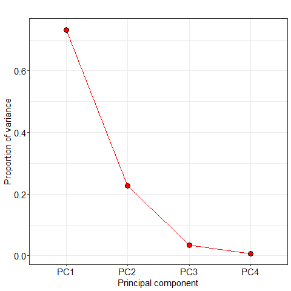

This plot illustrates the proportion of the variability explained by each principal component.

## Principal component loadings

|  | PC1 | PC2 | PC3 | PC4 |
| --- | --- | --- | --- | --- |
| Sepal length | 0.504 | -0.454 | 0.709 | 0.194 |
| Sepal width | -0.302 | -0.890 | -0.330 | -0.094 |
| Petal width | 0.567 | -0.037 | -0.585 | 0.578 |
| Petal length | 0.577 | -0.033 | -0.216 | -0.787 |

This table summarises the loadings of principal components. Responses with the larger absolute loadings have a greater influence on the corresponding principal component.

## Biplot of the first two principal components

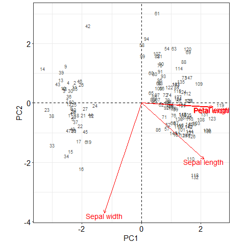

These axes are scaled to allow both loading and scores to be included on the same plot.

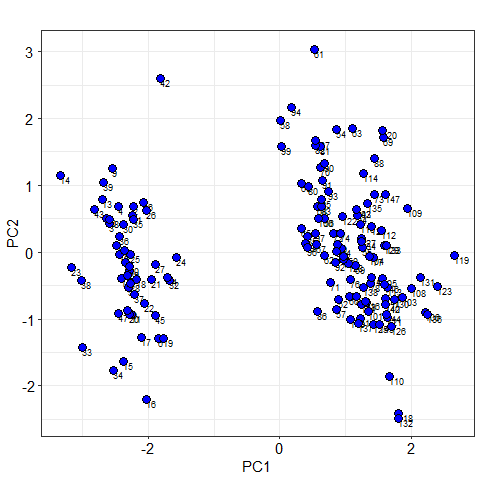

## References

When referring to InVivoStat, please cite 'InVivoStat, version 4.10'.

#### R references

R Core Team (2022). R: A language and environment for statistical computing. R Foundation for Statistical Computing, Vienna, Austria. URL https://www.R-project.org/.

Lecoutre, Eric (2003). The R2HTML Package. R News, Vol 3. N. 3, Vienna, Austria.

Schloerke B, Cook D, Larmarange J, Briatte F, Marbach M, Thoen E, Elberg A, Crowley J (2023). GGally: Extension to ggplot2. R package version 2.2.0, https://CRAN.R-project.org/package=GGally.

Neuwirth E (2022). RColorBrewer: ColorBrewer Palettes. R package version 1.1-3, https://CRAN.R-project.org/package=RColorBrewer.

H. Wickham. ggplot2: Elegant Graphics for Data Analysis. Springer-Verlag New York, 2016.

Slowikowski K (2024). ggrepel: Automatically Position Non-Overlapping Text Labels with ggplot2. R package version 0.9.5, https://CRAN.R-project.org/package=ggrepel.

H. Wickham. Reshaping data with the reshape package. Journal of Statistical Software, 21(12), 2007.

Hadley Wickham (2011). The Split-Apply-Combine Strategy for Data Analysis. Journal of Statistical Software, 40(1), 1-29. URL https://www.jstatsoft.org/v40/i01/.

Wickham H, Pedersen T, Seidel D (2023). scales: Scale Functions for Visualization. R package version 1.3.0, https://CRAN.R-project.org/package=scales.

Grothendieck G, Kates L, Petzoldt T (2016). proto: Prototype Object-Based Programming. R package version 1.0.0, https://CRAN.R-project.org/package=proto.

Genz A, Bretz F (2009). Computation of Multivariate Normal and t Probabilities, series Lecture Notes in Statistics. Springer-Verlag, Heidelberg. ISBN 978-3-642-01688-2.

## Analysis dataset

| Observation | Sepal length | Sepal width | Petal length | Petal width | Cases |
| --- | --- | --- | --- | --- | --- |
| 1 | 0.71 | 0.54 | 0.146 | -0.699 | 1 |
| 2 | 0.69 | 0.48 | 0.146 | -0.699 | 2 |
| 3 | 0.67 | 0.51 | 0.114 | -0.699 | 3 |
| 4 | 0.66 | 0.49 | 0.176 | -0.699 | 4 |
| 5 | 0.70 | 0.56 | 0.146 | -0.523 | 5 |
| 6 | 0.73 | 0.59 | 0.230 | -0.398 | 6 |
| 7 | 0.66 | 0.53 | 0.146 | -0.523 | 7 |
| 8 | 0.70 | 0.53 | 0.176 | -0.699 | 8 |
| 9 | 0.64 | 0.46 | 0.146 | -0.699 | 9 |
| 10 | 0.69 | 0.49 | 0.176 | -1.000 | 10 |
| 11 | 0.73 | 0.57 | 0.176 | -0.699 | 11 |
| 12 | 0.68 | 0.53 | 0.204 | -0.699 | 12 |
| 13 | 0.68 | 0.48 | 0.146 | -1.000 | 13 |
| 14 | 0.63 | 0.48 | 0.041 | -1.000 | 14 |
| 15 | 0.76 | 0.60 | 0.079 | -0.699 | 15 |
| 16 | 0.76 | 0.64 | 0.176 | -0.398 | 16 |
| 17 | 0.73 | 0.59 | 0.114 | -0.398 | 17 |
| 18 | 0.71 | 0.54 | 0.146 | -0.523 | 18 |
| 19 | 0.76 | 0.58 | 0.230 | -0.523 | 19 |
| 20 | 0.71 | 0.58 | 0.176 | -0.523 | 20 |
| 21 | 0.73 | 0.53 | 0.230 | -0.699 | 21 |
| 22 | 0.71 | 0.57 | 0.176 | -0.398 | 22 |
| 23 | 0.66 | 0.56 | 0.000 | -0.699 | 23 |
| 24 | 0.71 | 0.52 | 0.230 | -0.301 | 24 |
| 25 | 0.68 | 0.53 | 0.279 | -0.699 | 25 |
| 26 | 0.70 | 0.48 | 0.204 | -0.699 | 26 |
| 27 | 0.70 | 0.53 | 0.204 | -0.398 | 27 |
| 28 | 0.72 | 0.54 | 0.176 | -0.699 | 28 |
| 29 | 0.72 | 0.53 | 0.146 | -0.699 | 29 |
| 30 | 0.67 | 0.51 | 0.204 | -0.699 | 30 |

[output cut: 120 more lines]

## Analysis options

Response variables: Sepal length,Sepal width,Petal width,Petal length

Response variables transformation: log10

Analysis performed: Principal Components analysis

Response centering: Centered at zero

Response scale: Unit variance

Plot labels: Case ID